# This is my first attempt on building an image classifier

## Elk or Reindeer?

I will use this github repo as an inspiration: https://gist.github.com/KaiLicht/5b7692039455ec77c40a4ab8d6fb6f75 .

Since I am in Finland for a research visit at the moment, I thought I train a convolutional neural network to classify images of Elks and Reindeers correctly. Below are the individual steps.

```python
%reload_ext autoreload
%autoreload 2
%matplotlib inline
```

First, we have to install the google image downloader, in order to query google for the training and validation data

```python
!pip install google_images_download
```

Import the necessary libraries as per Lesson 1 of the Deep Learning fast.ai course

```python
from fastai import *
from fastai.vision import *
from fastai.metrics import error_rate
from google_images_download import google_images_download
import os
import PIL

os.getcwd()
```

```
'/data/course-v3/nbs/dl1'
```

Set path and number of pictures. The original author says that with the image downloader one can only download upt to 100 images, otherwise we will need to install chrome-driver

```python
PATH = "/data/course-v3/Example/ElkorReindeer/"
nof_pics = 100
```

Specify keywords and download path

```python
response = google_images_download.googleimagesdownload()

arguments = {"keywords":"Elk,Reindeer",
             "limit":nof_pics,
             "print_urls":False,
             "output_directory":f'{PATH}train',
             "chromedriver":"/usr/bin/chromedriver"}

paths = response.download(arguments)
```

[output not shown]

[output cut: 163 more lines]

```
Completed Image ====> 84.1018810.jpg
Completed Image ====> 85.wild-reindeer-of-iceland.jpg
Completed Image ====> 86.santa-reindeer-christmas-site.jpg
Completed Image ====> 87.315reindeer-portrait.jpg
Completed Image ====> 88.reindeer.jpg
Completed Image ====> 89.457dbd67cdf0391b53e5b415c02bcea0.jpg
Invalid or missing image format. Skipping...
Invalid or missing image format. Skipping...
Completed Image ====> 90.220px-Rentier_fws_1.jpg
Completed Image ====> 91.reindeer-disappearing-climate-change-2.jpg


Unfortunately all 100 could not be downloaded because some images were not downloadable. 91 is all we got for this search filter!

Errors: 9
```

This code/function is provided to check if there are corrupted images downloaded

```python
def check_images(PATH):
    broken_images=[]
    for pic_class in os.listdir(PATH):
        for pic in os.listdir(f'{PATH}/{pic_class}'):
            try:
                img = PIL.Image.open(f'{PATH}/{pic_class}/{pic}')
                img.verify()
            except (IOError, SyntaxError) as e:
                print('Bad file:', f'{PATH}/{pic_class}/{pic}')
                broken_images.append(f'{PATH}/{pic_class}/{pic}')
    return broken_images
```

```python
img_to_del = check_images(f'{PATH}train')
```

```python
[os.remove(pic) for pic in img_to_del]
```

```
[]
```

```python
def make_val_set(PATH, nof_val_pics):
    if not os.path.exists(f'{PATH}valid'):
        os.makedirs(f'{PATH}valid')
        for pic_class in os.listdir(f'{PATH}train'):
            os.makedirs(f'{PATH}valid/{pic_class}')
            for pic in random.sample(os.listdir(f'{PATH}train/{pic_class}'), nof_val_pics):
                os.rename(f'{PATH}train/{pic_class}/{pic}',
                          f'{PATH}valid/{pic_class}/{pic}')
    else:
        warnings.warn("The validation folder already exists! No validation set created.")
```

```python
make_val_set(PATH, 20)
```

Here we create the data bunch as per fastai

```python
data = ImageDataBunch.from_folder(PATH, ds_tfms=get_transforms(), size=224)
data.normalize(imagenet_stats)
```

```
ImageDataBunch;

Train: LabelList (205 items)
x: ImageList
Image (3, 224, 224),Image (3, 224, 224),Image (3, 224, 224),Image (3, 224, 224),Image (3, 224, 224)
y: CategoryList
Reindeer,Reindeer,Reindeer,Reindeer,Reindeer
Path: /data/course-v3/Example/ElkorReindeer;

Valid: LabelList (40 items)
x: ImageList
Image (3, 224, 224),Image (3, 224, 224),Image (3, 224, 224),Image (3, 224, 224),Image (3, 224, 224)
y: CategoryList
Reindeer,Reindeer,Reindeer,Reindeer,Reindeer
Path: /data/course-v3/Example/ElkorReindeer;

Test: None
```

Show some of the images to check if there are any issues

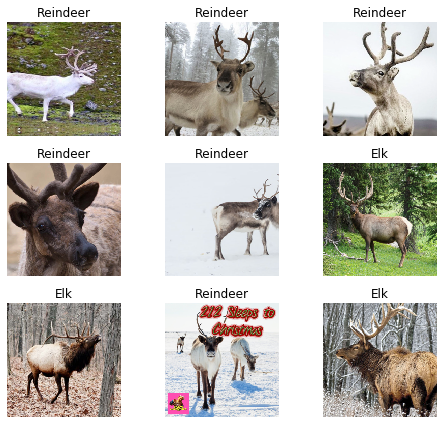

```python
data.show_batch(rows=3, figsize=(7,6))
```

Show the classes and number of classes for the images

```python
print(data.classes)
len(data.classes),data.c
```

```
['Elk', 'Reindeer']
```

```
(2, 2)
```

## Training: resnet34

Training the model can start now!

```python
learn = cnn_learner(data, models.resnet34, metrics=error_rate)
```

```python
learn.model
```

[output not shown]

[output cut: 99 more lines]

```
  (1): Sequential(
    (0): AdaptiveConcatPool2d(
      (ap): AdaptiveAvgPool2d(output_size=1)
      (mp): AdaptiveMaxPool2d(output_size=1)
    )
    (1): Flatten()
    (2): BatchNorm1d(1024, eps=1e-05, momentum=0.1, affine=True, track_running_stats=True)
    (3): Dropout(p=0.25)
    (4): Linear(in_features=1024, out_features=512, bias=True)
    (5): ReLU(inplace)
    (6): BatchNorm1d(512, eps=1e-05, momentum=0.1, affine=True, track_running_stats=True)
    (7): Dropout(p=0.5)
    (8): Linear(in_features=512, out_features=2, bias=True)
  )
)
```

```python
learn.fit_one_cycle(4)
```

| epoch | train_loss | valid_loss | error_rate | time |
| --- | --- | --- | --- | --- |
| 0 | 0.890051 | 0.606945 | 0.375000 | 00:18 |
| 1 | 0.575062 | 0.390406 | 0.125000 | 00:18 |
| 2 | 0.429228 | 0.372282 | 0.150000 | 00:19 |
| 3 | 0.332699 | 0.324001 | 0.175000 | 00:18 |

```python
learn.save('stage-1')
```

Let's see how we did!

```python
interp = ClassificationInterpretation.from_learner(learn)

losses,idxs = interp.top_losses()

len(data.valid_ds)==len(losses)==len(idxs)
```

```
True
```

This shows the images where the classifier really did not perform that well

[figure not shown]

```python
interp.plot_top_losses(9, figsize=(15,11))
```

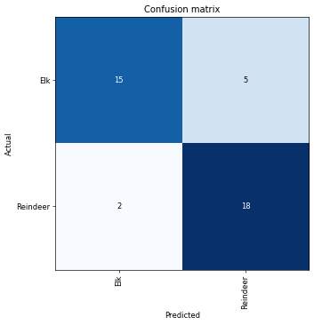

```python
interp.plot_confusion_matrix(figsize=(6,6), dpi=60)
```

```python
interp.most_confused(min_val=2)
```

```
[('Elk', 'Reindeer', 5), ('Reindeer', 'Elk', 2)]
```

## Unfreezing, fine-tuning, and learning rates, as per lesson 1

```python
learn.unfreeze()
```

```python
learn.fit_one_cycle(1)
```

| epoch | train_loss | valid_loss | error_rate | time |
| --- | --- | --- | --- | --- |
| 0 | 0.089902 | 0.467674 | 0.100000 | 00:22 |

```python
learn.load('stage-1');
```

```python
learn.lr_find()
```

```
LR Finder is complete, type {learner_name}.recorder.plot() to see the graph.
```

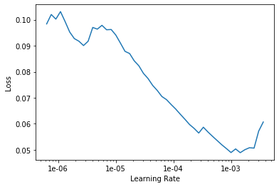

```python
learn.recorder.plot()
```

```python
learn.unfreeze()
learn.fit_one_cycle(2, max_lr=slice(1e-04,1e-03))
```

| epoch | train_loss | valid_loss | error_rate | time |
| --- | --- | --- | --- | --- |
| 0 | 0.134182 | 0.489001 | 0.100000 | 00:21 |
| 1 | 0.104497 | 0.251510 | 0.025000 | 00:23 |

```python
interp = ClassificationInterpretation.from_learner(learn)

losses,idxs = interp.top_losses()

len(data.valid_ds)==len(losses)==len(idxs)
```

```
True
```

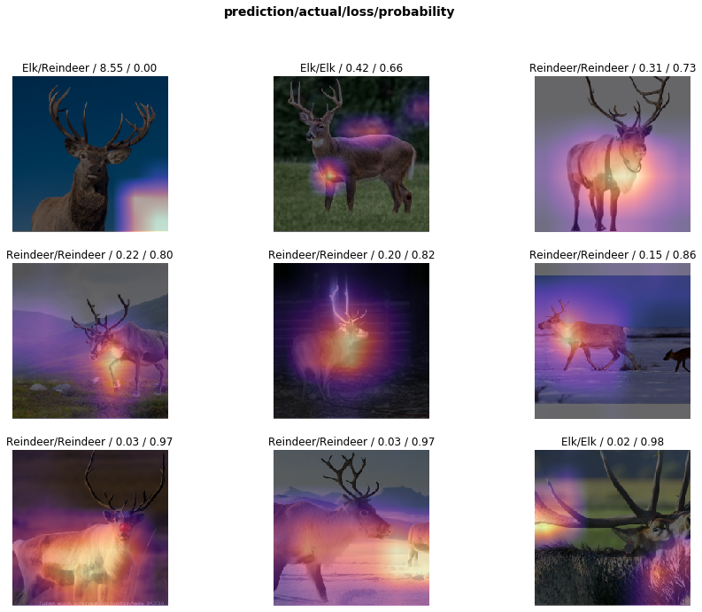

```python
interp.plot_top_losses(9, figsize=(15,11))
```

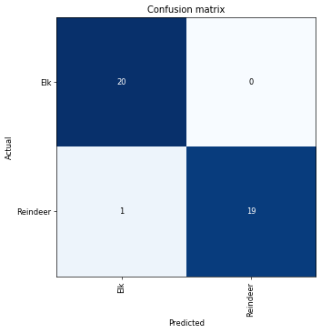

```python
interp.plot_confusion_matrix(figsize=(6,6), dpi=60)
```